# Generate Catch Profiles

Emma Fuller

May 17, 2014

## Cleaning fish ticket data

First step is filtering fish ticket data to fisheries of interest

The first step is to filter the fish ticket data to remove unspecified species, and fisheries we’re not interested in looking at. These are any unspecified species and shellfish. These are filtered by finding

- all species that have a `mgmt_grp` listing of `SHLL`
- any species in the following complexes

```
##   cmplx           descrip
## 1  CLAM       __ALL CLAMS
## 2  MLSK    __ALL MOLLUSKS
## 3  ECHN __ALL ECHINODERMS
## 4  OYST     __ALL OYSTERS
## 5  ABLN     __ALL ABALONE
```

- any species that has an “unspecified” or “other” label in their species name. There are 109 different species codes removed, see `remove_spid.csv` for the complete list. But a random 20 different examples are

```
##  [1] "OTHER ROCKFISH"          "OTHER OYSTER"
##  [3] "UNSP. SMALL REDS RCKFSH" "UNSP. KING CRAB"
##  [5] "UNSP. EELS"              "REMAINING FLATFISH"
##  [7] "GEN. SHELF/SLOPE RF"     "UNKNOWN SPECIES"
##  [9] "UNSP. SLOPE ROCKFISH"    "OTHER SKATES"
## [11] "UNSP. ROCKFISH"          "REMAINING ROUNDFISH"
## [13] "UNSP. JELLYFISH"         "UNSP. ROUNDFISH"
## [15] "UNSP. OCEAN SHRIMP"      "UNSP. ROSEFISH RCKFSH"
## [17] "UNSP. SHAD"              "__OTHER BSA RKFSH"
## [19] "OTHER CRAB"              "OTHER SCALLOP"
```

Filtering of trips happens in two steps. The first is to remove any trips in which these species make up the majority of catch. The second removes catch information for remaining trips.[^1]

After the data are filtered for species of interest, I remove species that occur in fewer than a total of 300 trips. This is because clustering algorithms will often make these their own clusters because they are so different than the rest of the data. To remove these trips I follow the same protocol as filtering for species of interest. First removing all trips in which these species are the majority of catch, and then removing any catch info from remaining trips.

To get this run `FTL_cp.R` in `2014-04-28/`

## PCA

The next step is to run a PCA to reduce the dimensionality. Currently there are 45 different species to cluster over. If some of these co-vary would like to condense that.

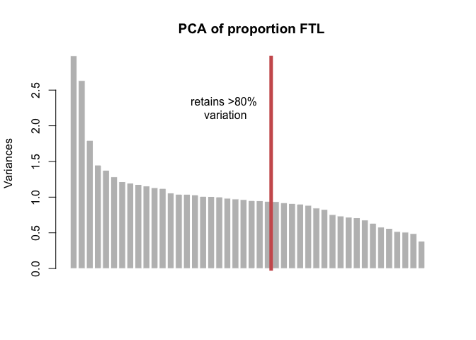

I can retain 30 principal components for clustering over.

## Clustering

I use this PCA data to cluster over. I first randomize the row order to prevent any bias from the order of the fish tickets, and then use CLARA because this is a big dataset (141939 trips).

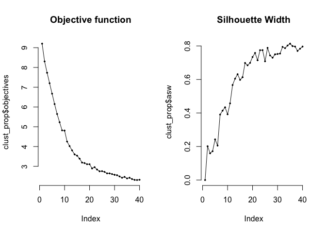

[^1]: This is important, because the majority of trips could catch cockles, but have a bit of petrale (obviously unrealistic), which is a species of interest. But if most of the catch was the removed species, the remaining catch info of the trip may be misleading. Thus all catch data for the entire trip is removed. After all trips with majority of species removed, then any remaining catch data for that species is removed, so that the clusters are not using it to define species clusters.